# Lab 2: Intro to data

Peter Baumgartner

2017/02/11

# Getting started

Some define statistics as the field that focuses on turning information into knowledge. The first step in that process is to summarize and describe the raw information – the data. In this lab we explore flights, specifically a random sample of domestic flights that departed from the three major New York City airport in 2013. We will generate simple graphical and numerical summaries of data on these flights and explore delay times. As this is a large data set, along the way you’ll also learn the indispensable skills of data processing and subsetting.

The [Bureau of Transportation Statistics](http://www.rita.dot.gov/bts/about/) (BTS) is a statistical agency that is a part of the Research and Innovative Technology Administration (RITA). As its name implies, BTS collects and makes available transportation data, such as the flights data we will be working with in this lab.

We begin by loading the nycflights data frame. Type the following in your console to load the data:

```r
data(nycflights)
```

The data set nycflights that shows up in your workspace is a data matrix, with each row representing an observation and each column representing a variable. R calls this data format a data frame, which is a term that will be used throughout the labs. For this data set, each observation is a single flight.

To view the names of the variables, type the command

```r
names(nycflights)
```

```
##  [1] "year"      "month"     "day"       "dep_time"  "dep_delay"
##  [6] "arr_time"  "arr_delay" "carrier"   "tailnum"   "flight"
## [11] "origin"    "dest"      "air_time"  "distance"  "hour"
## [16] "minute"
```

This returns the names of the variables in this data frame. The codebook (description of the variables) can be accessed by pulling up the help file:

```r
?nycflights
```

One of the variables refers to the carrier (i.e. airline) of the flight, which is [coded](http://www.transtats.bts.gov/DL_SelectFields.asp?Table_ID=236) according to the following system. (The link to the original information can be found in the discription of `airlines` from the package `nycflights13`.)

`carrier`: Two letter carrier abbreviation.

- `9E`: Endeavor Air Inc.
- `AA`: American Airlines Inc.
- `AS`: Alaska Airlines Inc.
- `B6`: JetBlue Airways
- `DL`: Delta Air Lines Inc.
- `EV`: ExpressJet Airlines Inc.
- `F9`: Frontier Airlines Inc.
- `FL`: AirTran Airways Corporation
- `HA`: Hawaiian Airlines Inc.
- `MQ`: Envoy Air
- `OO`: SkyWest Airlines Inc.
- `UA`: United Air Lines Inc.
- `US`: US Airways Inc.
- `VX`: Virgin America
- `WN`: Southwest Airlines Co.
- `YV`: Mesa Airlines Inc.

A very useful function for taking a quick peek at your data frame and viewing its dimensions and data types is str, which stands for structure.

**Description of `str()`**

*Compactly display the internal structure of an R object, a diagnostic function and an alternative to summary (and to some extent, dput). Ideally, only one line for each ‘basic’ structure is displayed. It is especially well suited to compactly display the (abbreviated) contents of (possibly nested) lists. The idea is to give reasonable output for any R object. It calls args for (non-primitive) function objects.*

```r
str(nycflights)
```

```
## Classes 'tbl_df' and 'data.frame':   32735 obs. of  16 variables:
##  $ year     : int  2013 2013 2013 2013 2013 2013 2013 2013 2013 2013 ...
##  $ month    : int  6 5 12 5 7 1 12 8 9 4 ...
##  $ day      : int  30 7 8 14 21 1 9 13 26 30 ...
##  $ dep_time : int  940 1657 859 1841 1102 1817 1259 1920 725 1323 ...
##  $ dep_delay: num  15 -3 -1 -4 -3 -3 14 85 -10 62 ...
##  $ arr_time : int  1216 2104 1238 2122 1230 2008 1617 2032 1027 1549 ...
##  $ arr_delay: num  -4 10 11 -34 -8 3 22 71 -8 60 ...
##  $ carrier  : chr  "VX" "DL" "DL" "DL" ...
##  $ tailnum  : chr  "N626VA" "N3760C" "N712TW" "N914DL" ...
##  $ flight   : int  407 329 422 2391 3652 353 1428 1407 2279 4162 ...
##  $ origin   : chr  "JFK" "JFK" "JFK" "JFK" ...
##  $ dest     : chr  "LAX" "SJU" "LAX" "TPA" ...
##  $ air_time : num  313 216 376 135 50 138 240 48 148 110 ...
##  $ distance : num  2475 1598 2475 1005 296 ...
##  $ hour     : num  9 16 8 18 11 18 12 19 7 13 ...
##  $ minute   : num  40 57 59 41 2 17 59 20 25 23 ...
```

`str()` has many optional parameters which I have not used yet. Look for more details into the help file.

With `tibble` there is a similar command: `glimpse`

**Description of `glimpse()`**

*This is like a transposed version of print: columns run down the page, and data runs across. This makes it possible to see every column in a data frame. It’s a little like str applied to a data frame but it tries to show you as much data as possible. (And it always shows the underlying data, even when applied to a remote data source.)*

```r
glimpse(nycflights)
```

```
## Observations: 32,735
## Variables: 16
## $ year      <int> 2013, 2013, 2013, 2013, 2013, 2013, 2013, 2013, 2013...
## $ month     <int> 6, 5, 12, 5, 7, 1, 12, 8, 9, 4, 6, 11, 4, 3, 10, 1, ...
## $ day       <int> 30, 7, 8, 14, 21, 1, 9, 13, 26, 30, 17, 22, 26, 25, ...
## $ dep_time  <int> 940, 1657, 859, 1841, 1102, 1817, 1259, 1920, 725, 1...
## $ dep_delay <dbl> 15, -3, -1, -4, -3, -3, 14, 85, -10, 62, 5, 5, -2, 1...
## $ arr_time  <int> 1216, 2104, 1238, 2122, 1230, 2008, 1617, 2032, 1027...
## $ arr_delay <dbl> -4, 10, 11, -34, -8, 3, 22, 71, -8, 60, -4, -2, 22, ...
## $ carrier   <chr> "VX", "DL", "DL", "DL", "9E", "AA", "WN", "B6", "AA"...
## $ tailnum   <chr> "N626VA", "N3760C", "N712TW", "N914DL", "N823AY", "N...
## $ flight    <int> 407, 329, 422, 2391, 3652, 353, 1428, 1407, 2279, 41...
## $ origin    <chr> "JFK", "JFK", "JFK", "JFK", "LGA", "LGA", "EWR", "JF...
## $ dest      <chr> "LAX", "SJU", "LAX", "TPA", "ORF", "ORD", "HOU", "IA...
## $ air_time  <dbl> 313, 216, 376, 135, 50, 138, 240, 48, 148, 110, 50, ...
## $ distance  <dbl> 2475, 1598, 2475, 1005, 296, 733, 1411, 228, 1096, 8...
## $ hour      <dbl> 9, 16, 8, 18, 11, 18, 12, 19, 7, 13, 9, 13, 8, 20, 1...
## $ minute    <dbl> 40, 57, 59, 41, 2, 17, 59, 20, 25, 23, 40, 20, 9, 54...
```

## Examples of research questions

The nycflights data frame is a massive trove of information. Let’s think about some questions we might want to answer with these data:

- How delayed were flights that were headed to Los Angeles?
- How do departure delays vary over months?
- Which of the three major NYC airports has a better on time percentage for departing flights?

# Analysis of Departure Delays

Let’s start by examing the distribution of departure delays of all flights with a histogram.

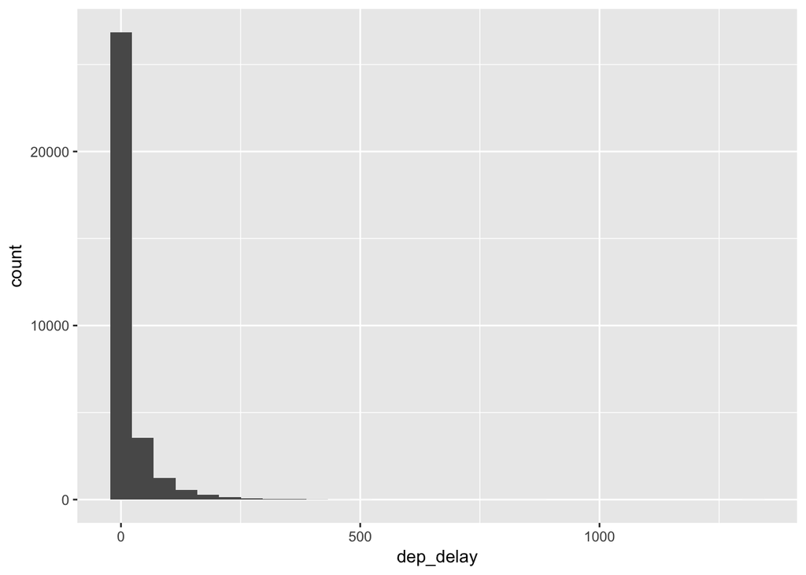

```r
qplot(x = dep_delay, data = nycflights, geom = "histogram")
```

This function says to plot the dep_delay variable from the nycflights data frame on the x-axis. It also defines a geom (short for geometric object), which describes the type of plot you will produce.

Histograms are generally a very good way to see the shape of a single distribution of numerical data, but that shape can change depending on how the data is split between the different bins. You can easily define the binwidth you want to use:

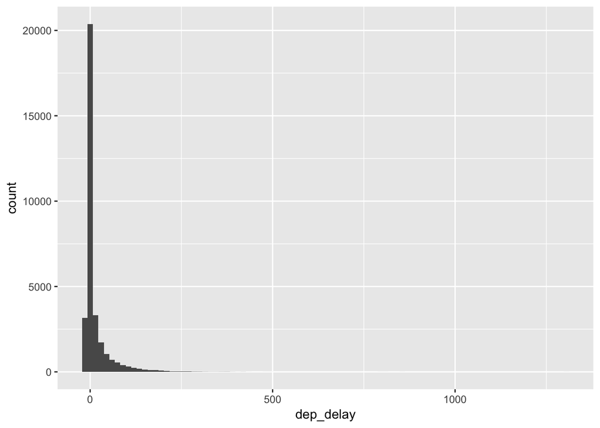

```r
qplot(x = dep_delay, data = nycflights, geom = "histogram", binwidth = 15)
```

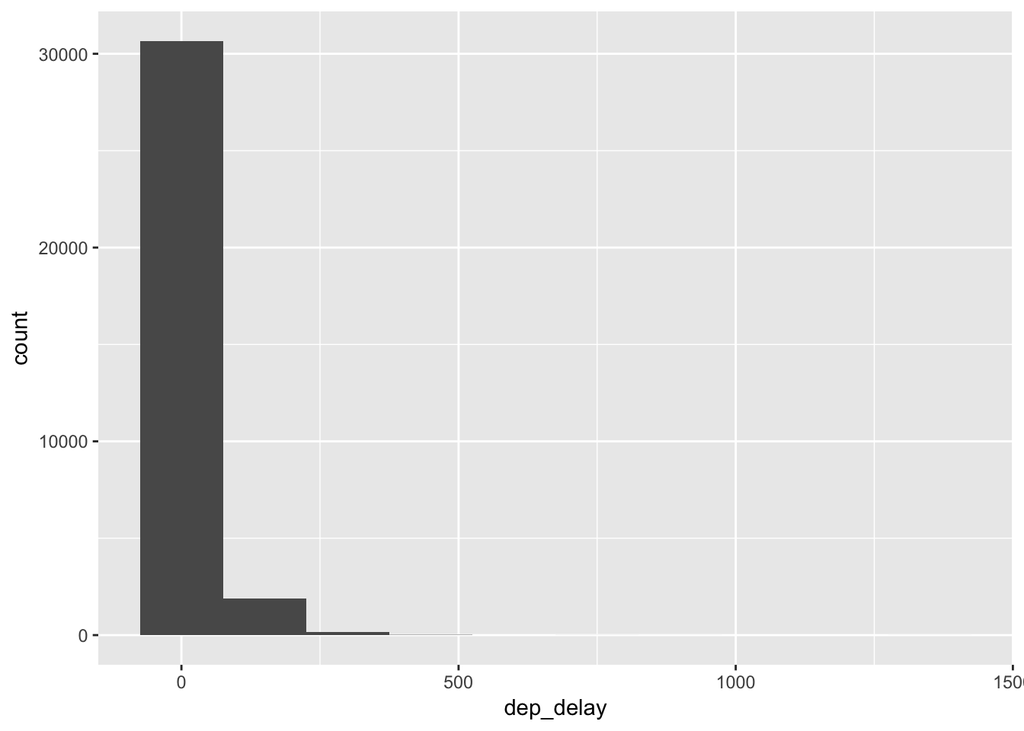

```r
qplot(x = dep_delay, data = nycflights, geom = "histogram", binwidth = 150)
```

I want to elaborate the histogram:

- Using ggplot
- Stretching the x-axis
- Labelling the graph

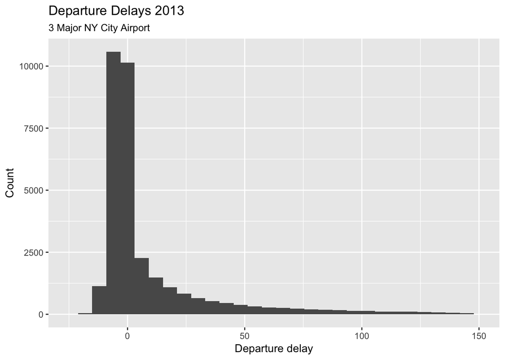

```r
p <- ggplot(nycflights, mapping = aes(dep_delay)) +
        labs(x = "Departure delay", y = "Count") +
        ggtitle(label = "Departure Delays 2013", subtitle = "3 Major NY City Airport") +
        xlim(-25, 150)
p + geom_histogram(bins = 30)
```

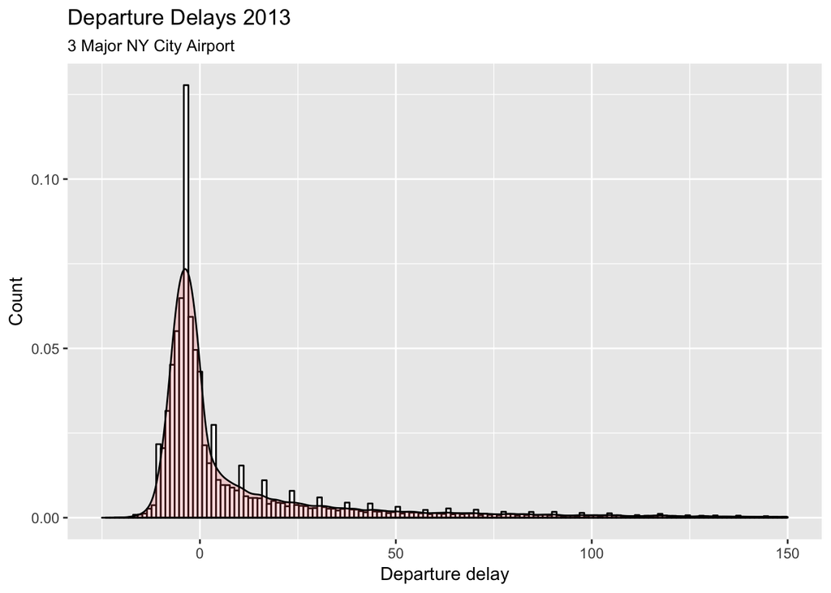

```r
p + geom_histogram(aes(y = ..density..),
                   bins = 150,
                   colour = "black",
                   fill = "white") +
        geom_density(alpha = .2, fill = "#FF6666")
```

## Exercise 1:

Look carefully at these three histograms. How do they compare? Are features revealed in one that are obscured in another?

- There are many flights leaving at an earlier time
- There are departure delay peaks (which cannot be seen with a small number of bins)

> **NOTE**: It is very crucial to experiment with (a) the number of bins in combination with (b) the scale of the axis, as these parameters change dramatically the histogram.

# My own exerpiment

I want to look into the difference of departure delays of the three different NY airports. My thinking goes about the follwing lines:

1. To filter these three different airports I need their code:

```r
head(nycflights$origin, 20)
```

```
##  [1] "JFK" "JFK" "JFK" "JFK" "LGA" "LGA" "EWR" "JFK" "LGA" "EWR" "JFK"
## [12] "LGA" "EWR" "LGA" "JFK" "EWR" "EWR" "JFK" "EWR" "JFK"
```

- `JFK`: [John F. Kennedy Airport](http://www.airport-jfk.com/)
- `LGA`: [LaGuardia Airport](http://laguardiaairport.com/)
- `EWR`: [Newark Airport](http://www.airport-ewr.com/)
2. For better processing I want to change the class of `nycflights$origin` from character to factor.

```r
nycflights$origin <- as.factor(nycflights$origin)
```

3. Compare summary data of departure delays by each of these three airports

```r
by_origin <- group_by(nycflights, origin)
summarise(by_origin, "Count" = n(), "Mean" = round(mean(dep_delay)), "Median" = median(dep_delay), "1st Qu." = quantile(dep_delay, 1/4), "3rd Qu." = quantile(dep_delay, 3/4), IQR = IQR(dep_delay), "SD" = round(sd(dep_delay), digits = 2), "Min" = min(dep_delay), "Max" = max(dep_delay))
```

```
## # A tibble: 3 × 10
##   origin Count  Mean Median `1st Qu.` `3rd Qu.`   IQR    SD   Min   Max
##   <fctr> <int> <dbl>  <dbl>     <dbl>     <dbl> <dbl> <dbl> <dbl> <dbl>
## 1    EWR 11771    15     -1        -4        15    19 41.76   -20   849
## 2    JFK 10897    12     -1        -5        10    15 40.03   -17  1301
## 3    LGA 10067    10     -3        -6         7    13 39.01   -21   803
```

4. Draw and compare histograms of departure delays for each airport

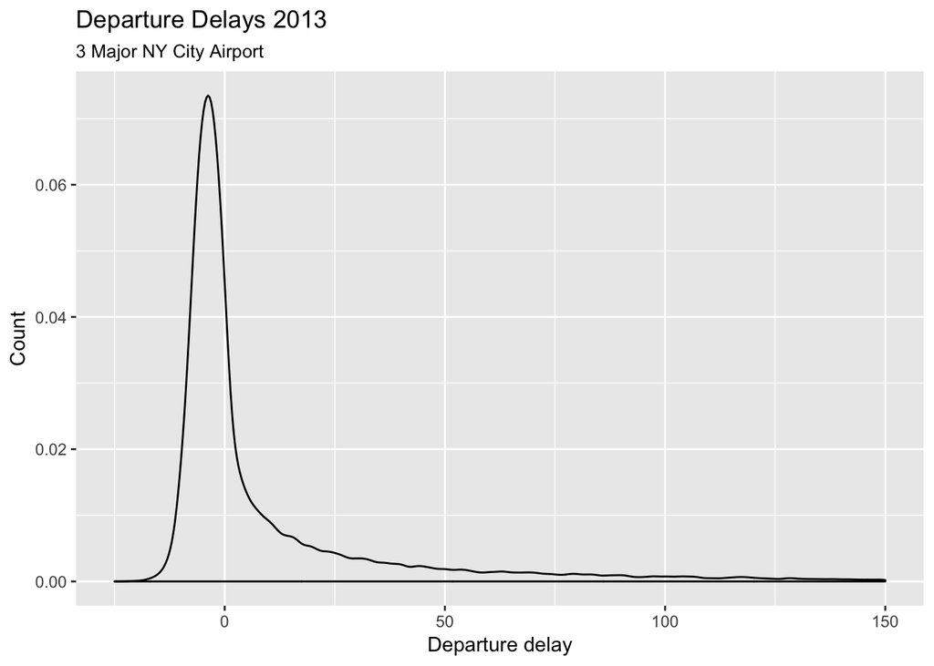

```r
p <- ggplot(by_origin, mapping = aes(dep_delay)) +
        labs(x = "Departure delay", y = "Count") +
        ggtitle(label = "Departure Delays 2013", subtitle = "3 Major NY City Airport") +
        xlim(-25, 150)
p + geom_density()
```

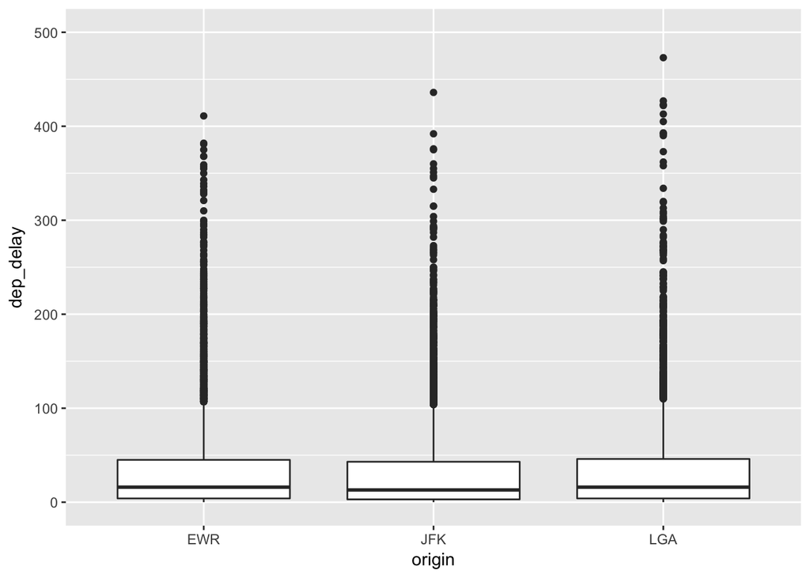

```r
p1 <- ggplot(by_origin, mapping = aes(origin, dep_delay)) +
        ylim(0, 500)
p1 + geom_boxplot()
```

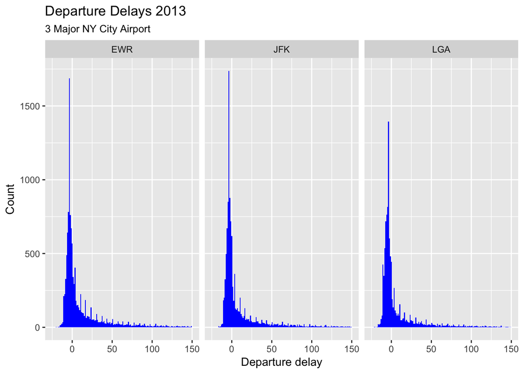

```r
p + geom_histogram(bins = 150,
                   fill = "blue") +
        facet_wrap(~ origin, nrow = 1)
```

# Result of my experiment

Working with the data set created other interesting research questions as well:

- Do departure delays differ by `carrier`?
- Do departure delays differ by `distance`, e.g. flights are catching up with long distances?
- What consequences on departure delays have arrival delays (`arr_delay`)?
- Are there special times where the frequency of departure delays is higer (e.g. rush hours)?

The number and variety of these generated research question show how important it is to inspect the data set thoroughly.

# Departure delay continued

If we want to focus only on departure delays of flights headed to Los Angeles, we need to first filter the data for flights with that destination (`dest == "LAX"`) and then make a histogram of the departure delays of only those flights.

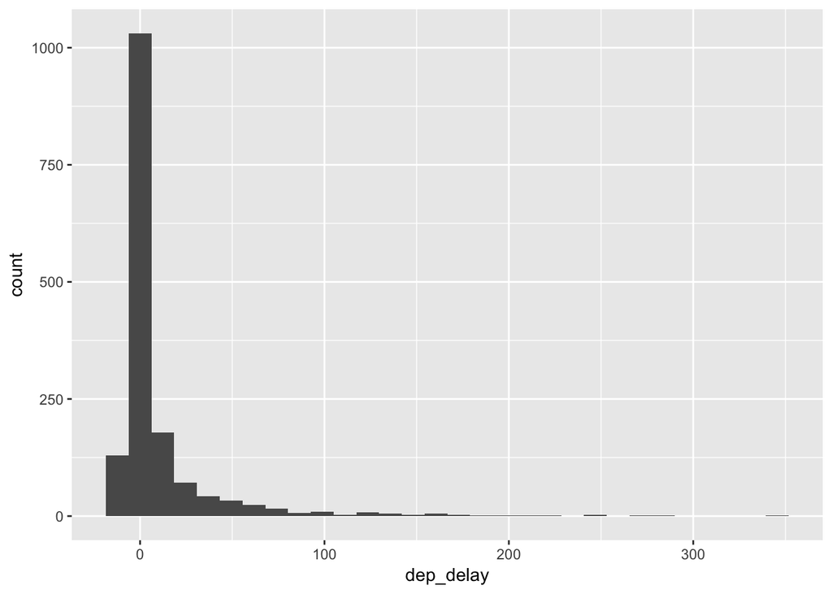

```r
lax_flights <- nycflights %>%
  filter(dest == "LAX")
qplot(x = dep_delay, data = lax_flights, geom = "histogram")
```

Let’s decipher these two commands (OK, so it might look like three lines, but the first two physical lines of code are actually part of the same command. It’s common to add a break to a new line after %>% to help readability).

- **Command 1**: Take the `nycflights data frame, filter for flights headed to LAX, and save the result as a new data frame called lax_flights.
  - == means “if it’s equal to”.
  - LAX is in quotation marks since it is a character string.
- **Command 2**: Basically the same `qplot` call from earlier for making a histogram, except that it uses the smaller data frame for flights headed to LAX instead of all flights.
  - Filtering for certain observations (e.g. flights from a particular airport) is often of interest in data frames where we might want to examine observations with certain characteristics separately from the rest of the data. To do so we use the `filter` function and a series of **logical operators**. The most commonly used logical operators for data analysis are as follows:
    - `==` means “equal to”
    - `!=` means “not equal to”
    - `>` or `<` means “greater than” or “less than”
    - `>=` or `<=` means “greater than or equal to” or “less than or equal to”

We can also obtain numerical summaries for these flights:

```r
lax_flights %>%
  summarise(mean_dd = mean(dep_delay), median_dd = median(dep_delay), n = n())
```

```
## # A tibble: 1 × 3
##    mean_dd median_dd     n
##      <dbl>     <dbl> <int>
## 1 9.782059        -1  1583
```

Note that in the summarise function we created a list of three different numerical summaries that we were interested in. The names of these elements are user defined, like mean_dd, median_dd, n, and you could customize these names as you like (just don’t use spaces in your names). [Spaces is also possible, but the names has to be quoted.] Calculating these summary statistics also require that you know the function calls. Note that `n()` reports the sample size.

**Summary statistics:** Some useful function calls for summary statistics for a single numerical variable are as follows: - `mean` - `median` - `sd` - `var` - `IQR` - `min` - `max`

Note that each of these functions take a single vector as an argument, and returns a single value. We can also filter based on multiple criteria. Suppose we are interested in flights headed to San Francisco (SFO) in February:

```r
sfo_feb_flights <- nycflights %>%
  filter(dest == "SFO", month == 2)
sfo_feb_flights2 <- nycflights %>%
  filter(dest == "SFO" & month == 2)
```

Note that we can separate the conditions using commas if we want flights that are both headed to SFO and in February. [But `&` results in the same outcome.] If we are interested in either flights headed to SFO or in February we can use the `|` instead of the comma.

## Exercise 2

Create a new data frame that includes flights headed to SFO in February, and save this data frame as sfo_feb_flights. How many flights meet these criteria?

68 flights meet these criteria.

## Exercise 3

Describe the distribution of the arrival delays of these flights using a histogram and appropriate summary statistics. Hint: The summary statistics you use should depend on the shape of the distribution.

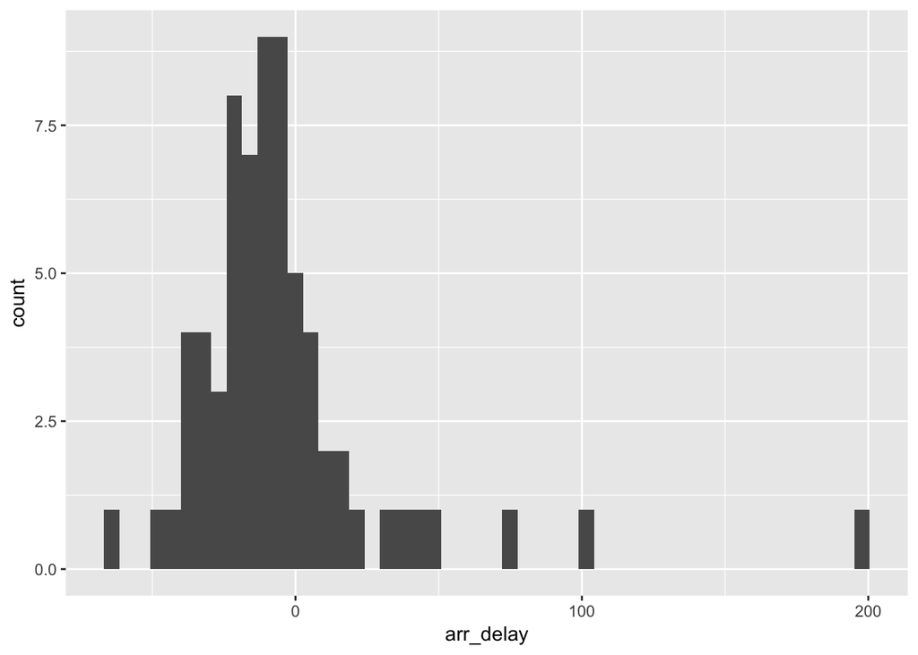

```r
ggplot(data = sfo_feb_flights, mapping = aes(x = arr_delay)) +
        geom_histogram(bins = 50)
```

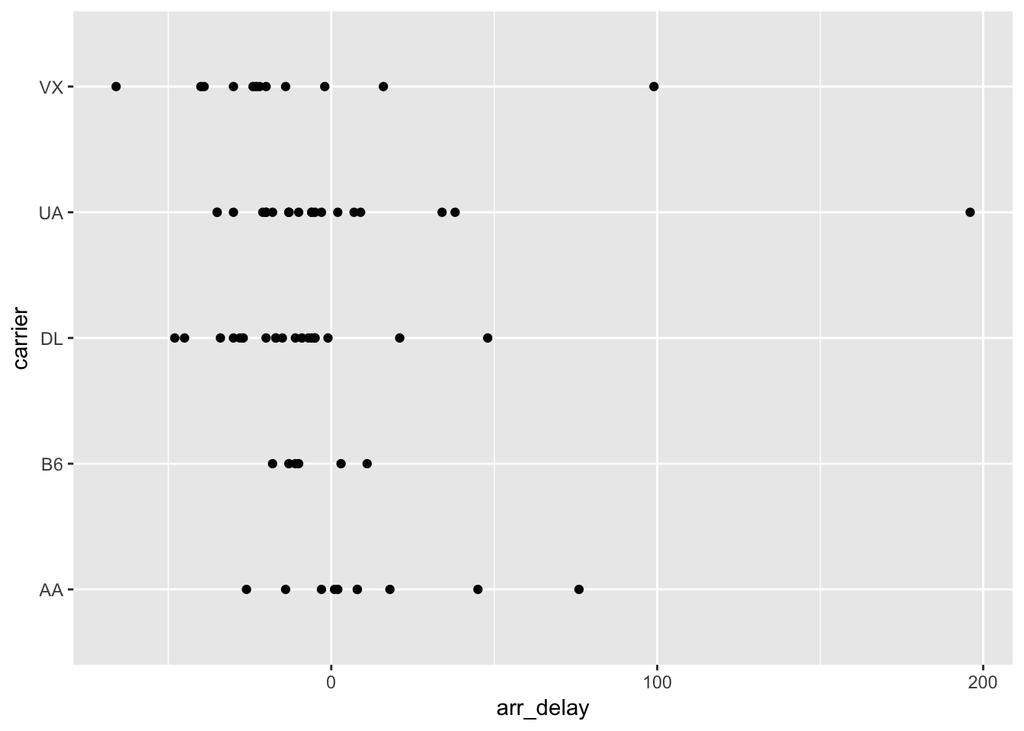

```r
ggplot(data = sfo_feb_flights, mapping = aes(x = arr_delay, y = carrier)) +
        geom_point()
```

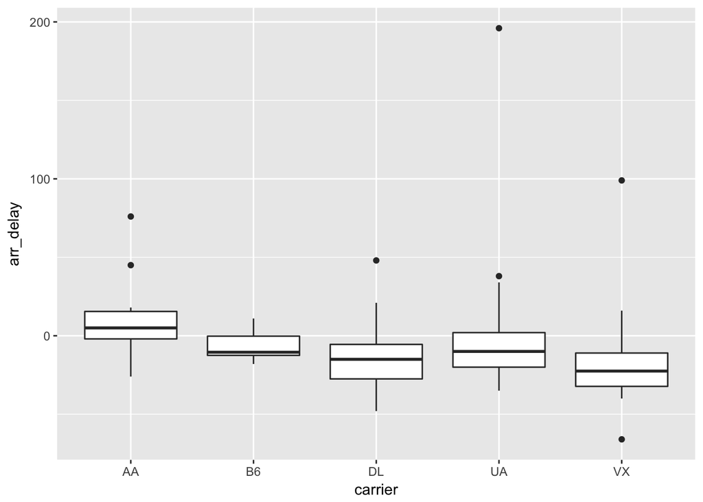

```r
ggplot(data = sfo_feb_flights, mapping = aes(x = carrier, y = arr_delay)) +
        geom_boxplot()
```

```r
arrival_more_than_one_hour_delayed <- filter(sfo_feb_flights, arr_delay > 60)

summary(sfo_feb_flights$arr_delay)
```

```
##    Min. 1st Qu.  Median    Mean 3rd Qu.    Max.
##  -66.00  -21.25  -11.00   -4.50    2.00  196.00
```

Half of the february flights to SFO arrived more than 11 minutes earlier. There are big differences of the arrival times by carrier. American Airlines (AA) as the carrier with the worst and Virgin America with the best arrival times. There are three cases where the arrival time is later than one hour.

Another useful technique is quickly calculating summary statistics for various groups in your data frame. For example, we can modify the above command using the group_by function to get the same summary stats for each origin airport:

```r
sfo_feb_flights %>%
  group_by(origin) %>%
  summarise(median_dd = median(dep_delay), iqr_dd = IQR(dep_delay), n_flights = n())
```

```
## # A tibble: 2 × 4
##   origin median_dd iqr_dd n_flights
##   <fctr>     <dbl>  <dbl>     <int>
## 1    EWR       0.5   5.75         8
## 2    JFK      -2.5  15.25        60
```

Here, we first grouped the data by origin, and then calculated the summary statistics.

```r
nycflights %>%
  group_by(carrier) %>%
  summarise(median_dd = median(dep_delay), iqr_dd = IQR(dep_delay), n_flights = n())
```

```
## # A tibble: 16 × 4
##    carrier median_dd iqr_dd n_flights
##      <chr>     <dbl>  <dbl>     <int>
## 1       9E      -1.0  23.25      1696
## 2       AA      -2.0   9.00      3188
## 3       AS      -4.5   8.75        66
## 4       B6      -1.0  18.00      5376
## 5       DL      -2.0   9.00      4751
## 6       EV      -1.0  31.00      5142
## 7       F9       1.0  18.00        69
## 8       FL       1.0  22.00       307
## 9       HA      -3.5   6.75        34
## 10      MQ      -3.0  16.00      2507
## 11      OO      -6.0  49.00         3
## 12      UA       0.0  14.00      5770
## 13      US      -4.0   7.00      2015
## 14      VX      -1.0  12.00       497
## 15      WN       1.0  19.00      1261
## 16      YV      -4.0  26.00        53
```

```r
by_carrier <- group_by(nycflights, carrier)
my_plot <- ggplot(by_carrier, mapping = aes(x = carrier, y = dep_delay)) +
        ylim(-30, 510) +
        geom_boxplot() +
        coord_flip()
ggsave("my_boxplot.pdf", width = 20, unit = "cm", device = "pdf")
```

```
## Saving 20 x 12.7 cm image
```

### Exercise 4

Calculate the median and interquartile range for `arr_delay`s of flights the `sfo_feb_flights` data frame, grouped by carrier. Which carrier has the most variable arrival delays?

```r
by_carrier_sfo_feb_flights <- group_by(sfo_feb_flights, carrier)
summarise(by_carrier_sfo_feb_flights, Median = median(arr_delay), IQR = IQR(arr_delay))
```

```
## # A tibble: 5 × 3
##   carrier Median   IQR
##     <chr>  <dbl> <dbl>
## 1      AA    5.0 17.50
## 2      B6  -10.5 12.25
## 3      DL  -15.0 22.00
## 4      UA  -10.0 22.00
## 5      VX  -22.5 21.25
```

United Airlines (UA) and Delta Airlines (DL) have the bigges interquartile rage for `arr_delay`s of flights the `sfo_feb_flights` data frame.

## Departe delays over month

Which month would you expect to have the highest average delay departing from an NYC airport?

Let’s think about how we would answer this question:

- First, calculate monthly averages for departure delays. With the new language we are learning, we need to
  - group_by months, then
  - summarise mean departure delays.
- Then, we need to arrange these average delays in descending order

```r
by_month <- group_by(nycflights, month)
dep_delay_by_month <- summarise(by_month,
                                Mean = round(mean(dep_delay), digits = 2),
                                Median = round(median(dep_delay), digits = 2),
                                IQR = IQR(dep_delay),
                                Max = max(dep_delay))
arrange(dep_delay_by_month, desc(Mean))
```

```
## # A tibble: 12 × 5
##    month  Mean Median   IQR   Max
##    <int> <dbl>  <dbl> <dbl> <dbl>
## 1      7 20.75      0    26   392
## 2      6 20.35      0    25   803
## 3     12 17.37      1    25   849
## 4      4 14.55     -2    16   427
## 5      3 13.52     -1    17   393
## 6      5 13.26     -1    19   351
## 7      8 12.62     -1    15   436
## 8      2 10.69     -2    15   319
## 9      1 10.23     -2    12  1301
## 10     9  6.87     -3     8   473
## 11    11  6.10     -2    10   413
## 12    10  5.88     -3     9   272
```

July, followed tightly by June is the month with the highest average delay of flights departing from an NYC airport. A high average mean of delay has also observed in December, suggesting that the problem lies in the number of flights during the Holidays. The months with the lowest average of departure delays are September to November.

### Exercise 5

Suppose you really dislike departure delays, and you want to schedule your travel in a month that minimizes your potential departure delay leaving NYC. One option is to choose the month with the lowest mean departure delay. Another option is to choose the month with the lowest median departure delay. What are the pros and cons of these two choices?

Median is more robust measure than the arithmetic mean, but the problem are the outliers. It could happen that one experiences one of these extra delayed flights. It seems to me that it is better to trust in this case the mean.

# On time departure rate for NYC airports

Suppose you will be flying out of NYC and want to know which of the three major NYC airports has the best on time departure rate of departing flights. Suppose also that for you a flight that is delayed for less than 5 minutes is basically “on time”. You consider any flight delayed for 5 minutes or of more to be “delayed”.

In order to determine which airport has the best on time departure rate, we need to

- first classify each flight as “on time” or “delayed”,
- then group flights by origin airport,
- then calculate on time departure rates for each origin airport,
- and finally arrange the airports in descending order for on time departure percentage.

Let’s start with classifying each flight as “on time” or “delayed” by creating a new variable with the mutate function.

```r
nycflights <- nycflights %>%
        mutate(ontime = dep_delay < 5) # my version

nycflights <- nycflights %>%
  mutate(dep_type = ifelse(dep_delay < 5, "on time", "delayed"))
```

The first argument in the mutate function is the name of the new variable we want to create, in this case dep_type. Then if dep_delay < 5 we classify the flight as “on time” and “delayed” if not, i.e. if the flight is delayed for 5 or more minutes.

Note that we are also overwriting the nycflights data frame with the new version of this data frame that includes the new dep_type variable.

We can handle all the remaining steps in one code chunk:

```r
nycflights %>%
        group_by(origin) %>%
        summarise(ontime_prop = sum(ontime == TRUE) / n()) %>%
        arrange(desc(ontime_prop))
```

```
## # A tibble: 3 × 2
##   origin ontime_prop
##   <fctr>       <dbl>
## 1    LGA   0.7279229
## 2    JFK   0.6935854
## 3    EWR   0.6369892
```

### Exercise 6

If you were selecting an airport simply based on on time departure percentage, which NYC airport would you choose to fly out of? I would choose LaGuardia.

We can also visualize the distribution of on on time departure rate across the three airports using a segmented bar plot.

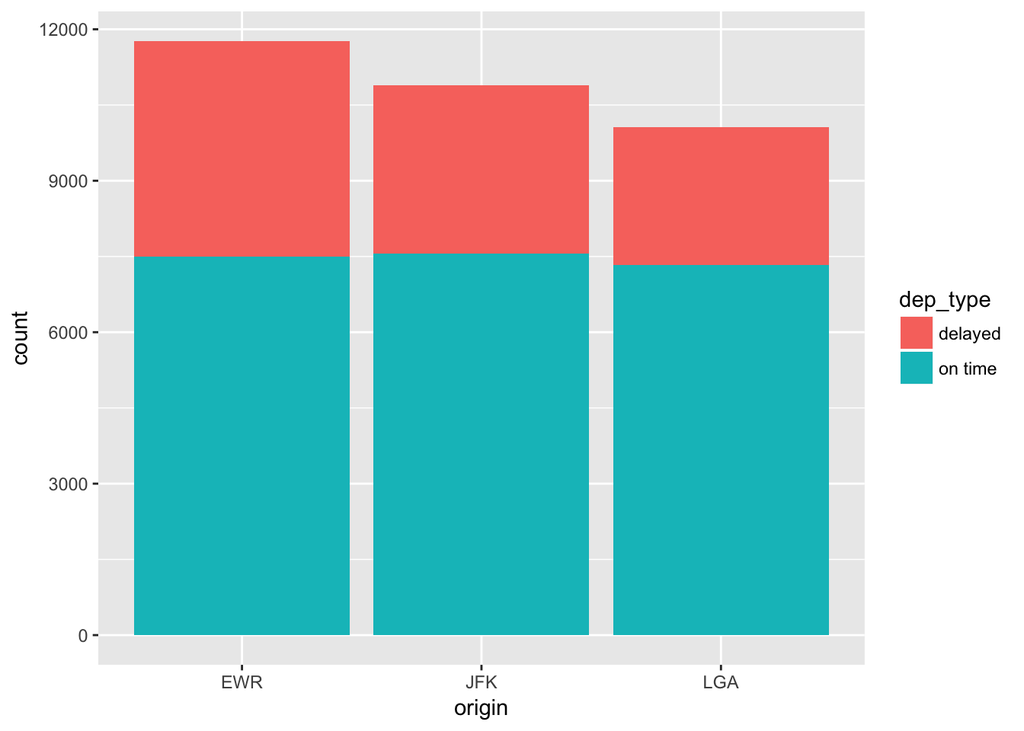

```r
qplot(x = origin, fill = dep_type, data = nycflights, geom = "bar")
```

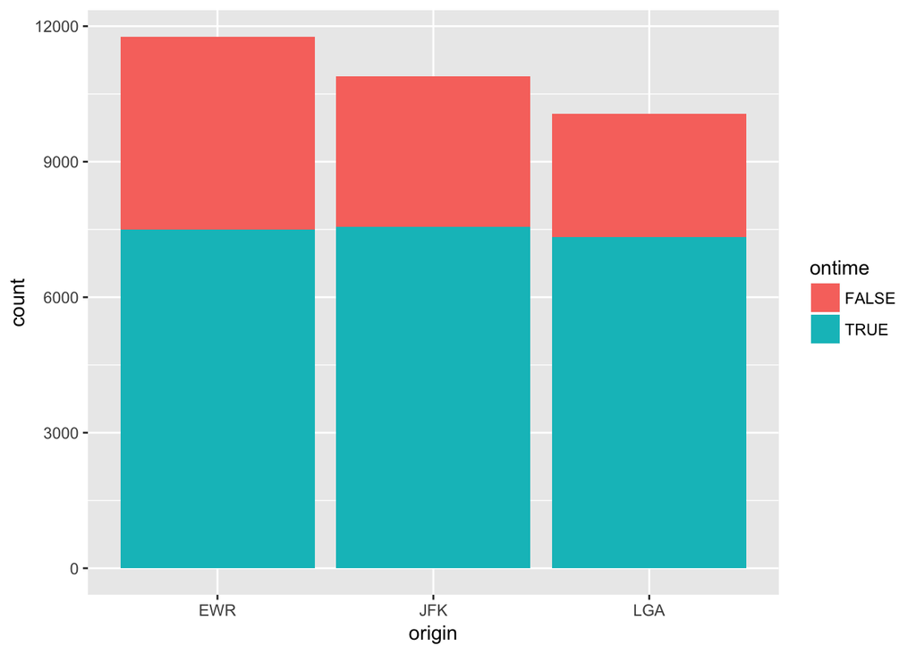

```r
ggplot(nycflights, aes(x = origin, fill = ontime)) +
        geom_bar()
```

# More practice

### Exercise 7

Mutate the data frame so that it includes a new variable that contains the average speed, `avg_speed` traveled by the plane for each flight (in mph). Hint: Average speed can be calculated as distance divided by number of hours of travel, and note that air_time is given in minutes.

```r
nycflights <- nycflights %>%
        mutate(avg_speed = distance / (air_time / 60))
```

### Exercise 8

8. Make a scatterplot of avg_speed vs. distance. Describe the relationship between average speed and distance. Hint: Use geom = “point”.

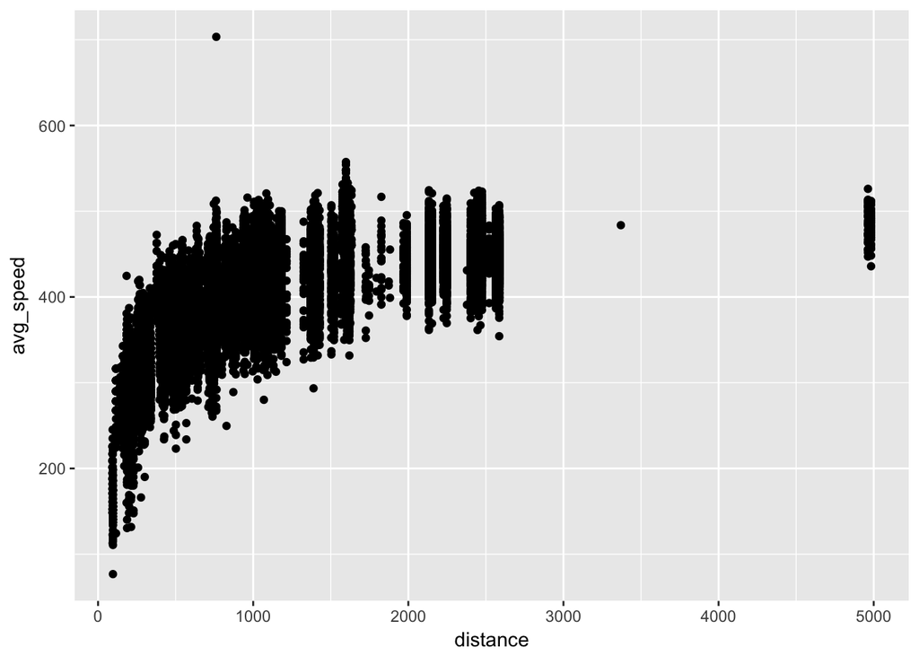

```r
ggplot(nycflights, aes(distance, avg_speed )) +
        # xlim(0, 2800) +
        # ylim(0, 600) +
        geom_point()
```

## Exercise 9

9. Replicate the following plot. Hint: The data frame plotted only contains flights from American Airlines, Delta Airlines, and United Airlines, and the points are `color`ed by `carrier`. Once you replicate the plot, determine (roughly) what the cutoff point is for departure delays where you can still expect to get to your destination on time.

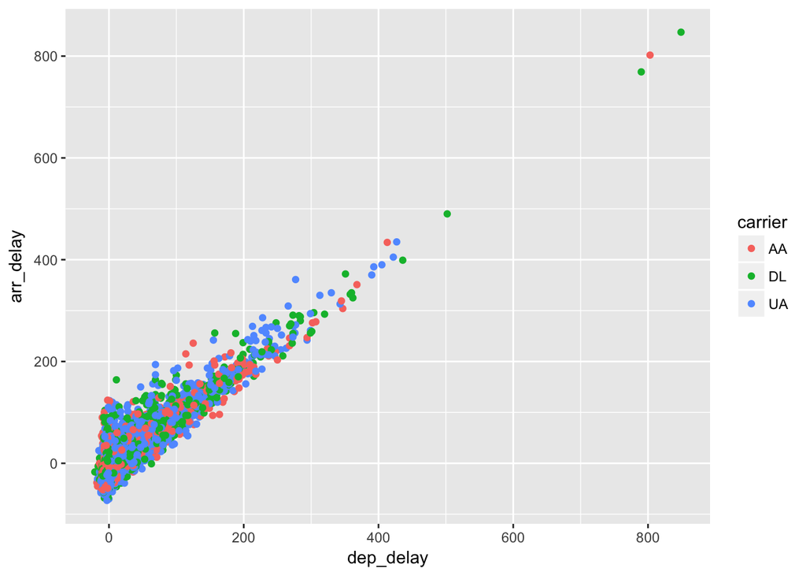

```r
dl_aa_ua <- nycflights %>%
  filter(carrier == "AA" | carrier == "DL" | carrier == "UA")
qplot(x = dep_delay, y = arr_delay, data = dl_aa_ua, color = carrier)
```

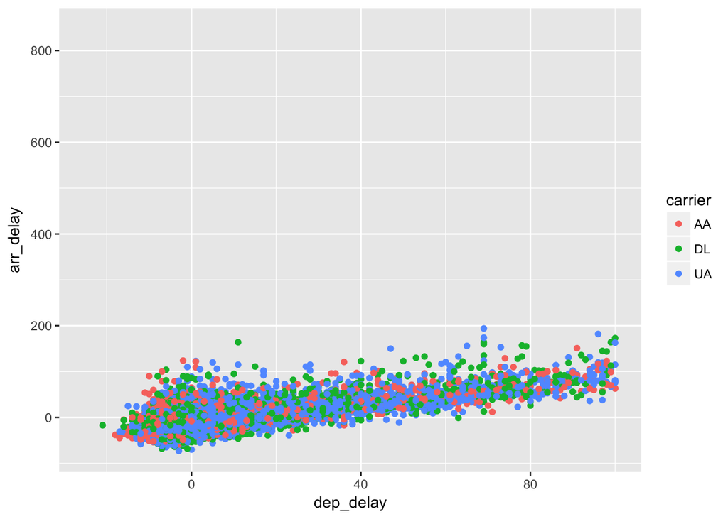

```r
ggplot(dl_aa_ua, aes(x = dep_delay, y = arr_delay, color = carrier)) +
        xlim(-25, 100) +
        geom_point()
```

The cutoff point for departure delays where you can still expect to get to your destination on time is roughly about 20 to maximal 40 minutes.